# Handbook for the Stochastic Production model in Continuous Time (SPiCT)

### 2.11.2 Management

In addition to manually changing the forecast period and fishing factor as described above, SPiCT includes a wide range of functions related to fisheries management. The `manage` function applies 8 different management scenarios and allows to explore the effect of different management strategies on the recommended Total Allowable Catch (TAC), or predicted fishing mortality or biomass. The scenarios include advice rules such as constant catch, no fishing or the current advice rule recommended by the export group for data limited fisheries management in ICES (ICES 2019). The results of this function are appended to the `spictcls` object, thus the application is straight-forward:

```r
inp <- pol$albacore
rep <- fit.spict(inp)
rep <- manage(rep)
   Selected scenario(s):  currentCatch, currentF, Fmsy, noF, reduceF25, increaseF25, msyHockeyStick, ices
```

More information about these advice rules and other functionality of the `manage` function can be found in the function documentation (`?manage`).

The results of the management scenarios can be summarised by:

```r
sumspict.manage(rep)
   SPiCT timeline:

         Observations              Management
       1967.00 - 1990.00        1990.00 - 1991.00
    |-----------------------| ----------------------|

   Management evaluation: 1991.00

   Predicted catch for management period and states at management evaluation time:

                                 C B/Bmsy F/Fmsy
   1. Keep current catch      25.2   0.89   1.23
   2. Keep current F          24.7   0.89   1.20
   3. Fish at Fmsy            21.3   0.95   1.00
   4. No fishing               0.0   1.30   0.00
   5. Reduce F by 25%         19.4   0.98   0.90
   6. Increase F by 25%       29.5   0.81   1.50
   7. MSY hockey-stick rule   21.3   0.95   1.00
   8. ICES advice rule (2025) 19.3   0.98   0.89
```

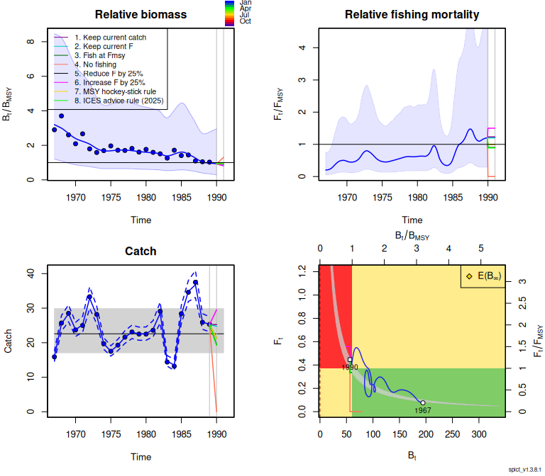

```r
plot2(rep)
```

If any plotting function of the `plotspict.` family is called on a SPiCT object which includes management scenarios (`rep$man != NULL`), the prediction and confidence intervals of the base scenario (`rep`) are omitted from the plot and instead the projections of the different management scenarios are displayed in different colours. The grey vertical line corresponding to the time of the last observation in the standard plots is replaced by two lines which corresponds to the start and end of the management interval. In some cases, there might only be one vertical line displayed in the catch plot or the trajectories of the scenarios might be missing in the catch plot. Refer to the function documentation if that is the case (`help(plotspict.catch)`). In order to go back to the previous plots, one can remove the management scenarios (see below) or assign the results of the `manage` function to a different object, e.g. `man <- manage(rep)` and have both plotting functionalities with `plot(rep)` and `plot(man)`.

The function `plotspict.hcr` (spict version >= 1.3.4) provides a visual summary of the management scenarios.

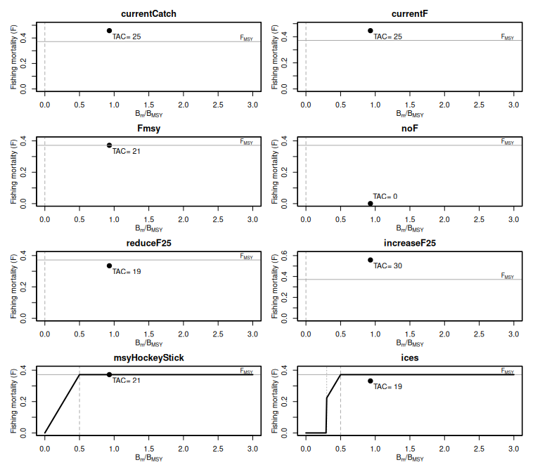

```r
plotspict.hcr(rep)
```

#### 2.11.2.1 Assessment and intermediate period

Besides defining the assessment period in the input data as shown above, it can also be changed in the `manage` function directly using the argument `maninterval`. The management period or interval can correspond to any period from a fraction of a year to spanning over several years (see below for more examples of variable assessment periods). To visualise the management period the function `man.timeline` can be applied to an input list:

```r
man.timeline(inp)
   SPiCT timeline:

         Observations              Management
       1967.00 - 1990.00        1990.00 - 1991.00
    |-----------------------| ----------------------|

   Management evaluation: 1991.00
```

or to a fitted spict object:

```r
man.timeline(rep)
   SPiCT timeline:

         Observations              Management
       1967.00 - 1990.00        1990.00 - 1991.00
    |-----------------------| ----------------------|

   Management evaluation: 1991.00
```

As the output shows, the management period period starts right after the time of the last observation, in this example in 1990. In reality, however, there is often a lag between the data and management period. In fact, the assessment is often performed within the gap year and the management scenarios are supposed to start at the beginning of the following year. Thus, it makes sense to distinguish the intermediate period from the management period. For the albacore data set we could assume a management period starting in 1991, which would change the time line as follows:

```r
inp$maninterval <- c(1991,1992)
man.timeline(inp)
   SPiCT timeline:

         Observations             Intermediate             Management
       1967.00 - 1990.00        1990.00 - 1991.00       1991.00 - 1992.00
    |-----------------------| ----------------------| ----------------------|

   Management evaluation: 1992.00
```

As can be seen, the timeline includes an additional section called ‘Intermediate’ referring to the intermediate period. Management scenarios with an intermediate period from 1990 to 1991 and an assessment period can thus be specified for the albacore data set with:

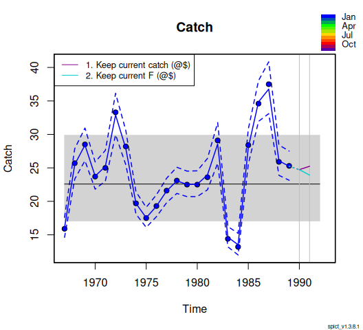

```r
repIntPer <- manage(rep, scenarios = c(1,2),
                    maninterval = c(1991,1992), maneval = 1992)
   Selected scenario(s):  currentCatch, currentF
plotspict.catch(repIntPer)
```

It is important to note that defining a management interval a few time steps after the time of the last catch observation requires the model to make an assumption about the fishing mortality during the intermediate period. By default, SPiCT continues the fishing mortality process in the intermediate period, i.e. the fishing mortality corresponds to the estimated F at the time step of the last observation and the estimated seasonal F process. However, in some cases it might be meaningful to assume a certain catch during this period rather than continuing the F process. This might be in particular relevant when information about the catch in the intermediate period is available, for example in form of a TAC which was recommended and implemented the year before. Therefore, a specific catch can be specified for the intermediate period using the argument `intermediatePeriodCatch`.

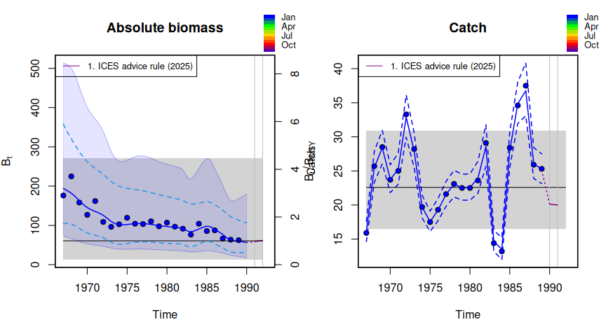

```r
repIntPerC <- manage(rep, scenarios=c(8), maninterval = c(1991,1992), intermediatePeriodCatch = 20)
   Selected scenario(s):  ices
par(mfrow=c(1,2))
plotspict.biomass(repIntPerC)
plotspict.catch(repIntPerC)
```

As the graph shows, the catch in the intermediate period has been set to 20t (year 1990). Dotted lines of the management scenarios reflect the intermediate period, while solid lines reflect the management period. Be aware that the vertical bars indicating the start and end of the management period might seem off by a year for the catch plot, however, they correspond to the timing of the catch observations which are drawn at the beginning of the catch interval they refer to.

Note that the specified catch corresponds to the complete intermediate period, which might be a year, but could also be quarter of a year or 3 years depending on the time of the last observation and the start of the management period (see below for examples with variable intermediate periods). Note further, that the catch used for the scenario ‘currentCatch’ is the last observed catch even though a certain catch is provided in the intermediate period. The argument `intermediatePeriodCatchList` allows to specify any number of catch ‘observations’ corresponding to any interval during the intermediate period. It is a list with the elements ‘obsC’, ‘timeC’, ‘dtc’ and the optional element ‘stdevfacC’ (which is equal to 1 if not provided). Find more information about this and related arguments in the documentation of the `manage` function.

#### 2.11.2.2 Custom management scenarios

The default management scenarios included in the `manage` function are a selection of advice rules that are relevant to managers and stakeholders, in particular, based on our experience with stocks managed by ICES. However, there is no limitation in terms of custom advice rules and management scenarios. The function `add.man.scenario` allows to define a wide range of management scenarios and creates a new spict object, which can easily be added to exiting scenarios in `rep$man` (contrary to `manage` which overwrites all scenarios in `rep$man`). For example, to add an additional management scenario to `repIntPer` which increases fishing mortality by 50%:

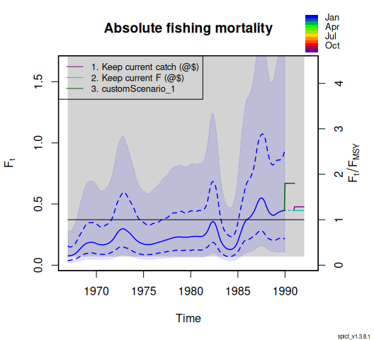

```r
repIntPer <- add.man.scenario(repIntPer, ffac = 1.5)
sumspict.manage(repIntPer)
   SPiCT timeline:

         Observations             Intermediate             Management
       1967.00 - 1990.00        1990.00 - 1991.00       1991.00 - 1992.00
    |-----------------------| ----------------------| ----------------------|

   Management evaluation: 1992.00

   Predicted catch for management period and states at management evaluation time:

                                 C B/Bmsy F/Fmsy
   1. Keep current catch (@$) 25.2   0.85   1.28
   2. Keep current F (@$)     23.9   0.87   1.20
   3. customScenario_1        33.9   0.74   1.80
   (@) This scenario assumes another management period. Thus, the estimates might not be comparable to the other scenarios.
   ($) This scenario assumes another management evaluation time. Thus, the estimates might not be comparable to the other scenarios.
plotspict.f(repIntPer)
```

```r
repIntPer <- add.man.scenario(repIntPer, cfac = 0.64,
                              scenarioTitle = "reduced_catch")
names(repIntPer$man)
   [1] "currentCatch"     "currentF"         "customScenario_1" "reduced_catch"
```

Note that the fractile for the $F/F_{MSY}$ distribution is actually 1 minus the fractile specified. Otherwise, a larger fractile would be more precautionary than a smaller one, as the current fishing mortality is divided by the value of this distribution ($F_{y+1} = \frac{F_y}{\frac{F_y}{F_{MSY}}}$). This allows a consistent setting of fractiles among the different quantities.

The advice rule recommended by ICES (2019) can thus be defined by the combination of several of these arguments:

```r
repIntPer <- add.man.scenario(repIntPer, scenarioTitle = "ices",
                              breakpointB = 0.5,
                              fractiles = list(catch=0.35, bbmsy=0.35, ffmsy=0.35))
sumspict.manage(repIntPer)
   SPiCT timeline:

         Observations             Intermediate             Management
       1967.00 - 1990.00        1990.00 - 1991.00       1991.00 - 1992.00
    |-----------------------| ----------------------| ----------------------|

   Management evaluation: 1992.00

   Predicted catch for management period and states at management evaluation time:

                                 C B/Bmsy F/Fmsy
   1. Keep current catch (@$) 25.2   0.85   1.28
   2. Keep current F (@$)     23.9   0.87   1.20
   3. customScenario_1        33.9   0.74   1.80
   4. reduced_catch           16.2   1.04   0.73
   5. ICES advice rule (2025) 15.0   1.06   0.67
   (@) This scenario assumes another management period. Thus, the estimates might not be comparable to the other scenarios.
   ($) This scenario assumes another management evaluation time. Thus, the estimates might not be comparable to the other scenarios.
```

A detailed description of all arguments of this function can be found in the function documentation (run `?add.man.scenario`).

#### 2.11.2.3 Variable management periods

As mentioned above, the management period (and intermediate period) is not limited to the length of one year nor to the start of a year, but can span half a year, several years or start within any point in time within the year (cf. in-year advice ICES (2019)). For example, applying two default scenarios for a half year period starting in the middle of 1990:

```r
repVarPer <- manage(rep, scenarios = c(1,4), maninterval = c(1990.5,1991))
   Selected scenario(s):  currentCatch, noF
```

Scenarios with different management intervals can also be combined, although the functions will print a note about mismatching periods or assumptions in the intermediate period. For example, to add an advice rule which reduces the F linearly to zero if the biomass is below 50% of $B/B_{MSY}$ over a management interval of 2 years to the previous scenarios:

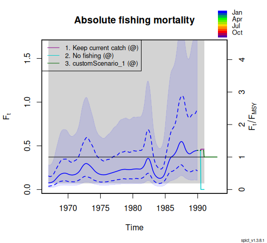

```r
repVarPer <- add.man.scenario(repVarPer, maninterval = c(1991, 1993),
                              breakpointB = 0.5)
plotspict.f(repVarPer)
```

```r
sumspict.manage(repVarPer)
   SPiCT timeline:

         Observations             Intermediate             Management
       1967.00 - 1990.00        1990.00 - 1990.50       1990.50 - 1991.00
    |-----------------------| ----------------------| ----------------------|

   Management evaluation: 1991.00

   Predicted catch for management period and states at management evaluation time:

                                C B/Bmsy F/Fmsy
   1. Keep current catch (@) 12.6   0.89   1.24
   2. No fishing (@)          0.0   1.10   0.00
   3. customScenario_1 (@)   41.7   0.89   1.00
   (@) This scenario assumes another management period. Thus, the estimates might not be comparable to the other scenarios.
```

#### 2.11.2.4 Advanced management settings and functionality

Besides selecting scenarios in `manage` using the argument `scenarios`, the function `man.select` can be used to change the order of scenarios or omit certain or all scenarios included in `rep$man`:

```r
names(rep$man)
   [1] "currentCatch"   "currentF"       "Fmsy"           "noF"
   [5] "reduceF25"      "increaseF25"    "msyHockeyStick" "ices"
rep <- man.select(rep, scenarios = c(1,3))
   Selected scenario(s):  currentCatch, Fmsy
```

One of the important quantities in fisheries management is the predicted catch during the management interval under given fishing mortality, also called Total Allowable Catch (TAC). The function `man.tac` allows to extract a list with the TAC of all scenarios in `rep$man`:

```r
man.tac(rep)
   $currentCatch
   [1] 25.23698

   $Fmsy
   [1] 21.25495
```

Note that the unit of the TAC corresponds to the catch unit specified in `inp$catchunit` or the unit of the catch observations if not specified. If the user is only interested in the TAC of the specified management scenario (e.f. for the implementation in a management strategy framework (MSE)), the function `get.TAC` can be used:

```r
get.TAC(rep, maninterval = c(1990.25, 1991),
        safeguardB = list(limitB = 0.3), verbose = TRUE)
   Note that the specified management interval: 1990.25 - 1991.00 differs from existing scenarios in rep$man.
   [1] 15.73663
```

After comparing the implications of different management scenarios, it might be of interest to extract a specific scenario for further analyses, plotting, or reporting. Specific scenarios can be extracted from the SPiCT object by referencing their names or positioning in the list `rep$man`, e.g. `rep$man[[1]]`. However, care has to be taken, as some scenarios (e.g. ‘constantCatch’ or scenarios with a specified catch in the intermediate period) might include additional catch observations. Thus, the best way to select certain scenarios is by means of the function `man.select`. This function does not only allow to change the order of the management scenarios in `rep$man` or make a selection of scenarios, but also allows to extract a certain scenario as a standard SPiCT object of the class `spictcls`:

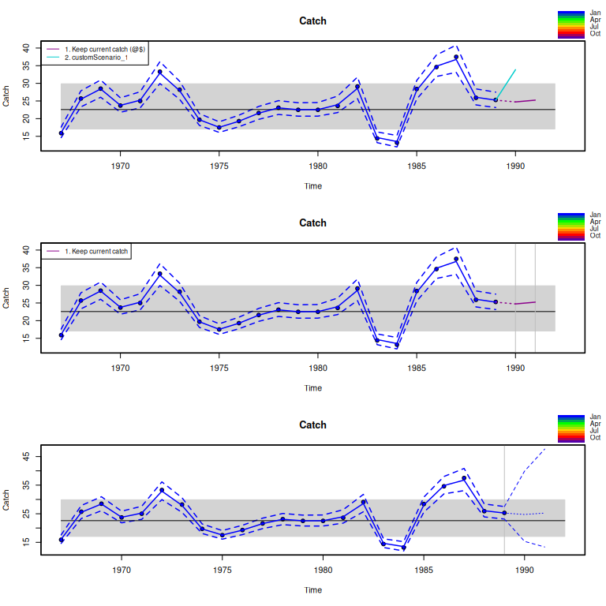

```r
## selection by index
length(repIntPer$man)
   [1] 5
repSelect1 <- man.select(repIntPer, scenarios = c(3,1))
   Selected scenario(s):  currentCatch, customScenario_1

## selection by scenario name
names(repIntPer$man)
   [1] "currentCatch"     "currentF"         "customScenario_1" "reduced_catch"
   [5] "ices"
repSelect2 <- man.select(repIntPer, scenarios = c("currentCatch"))
   Selected scenario(s):  currentCatch

## selected object as standard spictcls object
repSelect3 <- man.select(repIntPer, scenarios = c("currentCatch"), spictcls = TRUE)

## Plot objects with selected scenarios
opar <- par(mfrow=c(3,1))
plotspict.catch(repSelect1)
plotspict.catch(repSelect2)
plotspict.catch(repSelect3)
par(opar)
```

Note the different catch trajectories of the second and third plot. Although, the same scenario was selected, the first approach still shows the management-type plot, while the second approach (with argument `spictcls = TRUE`) shows the default ‘spictcls’ catch plot with predicted uncertainties.

All management related results can easily be removed from the SPiCT object by overwriting the `man` element: `rep$man = NULL` or

```r
rep <- man.select(rep, scenarios = NULL)
   All scenarios removed!
```

# 3 Other model settings and options

## 3.1 `catchunit` - Define unit of catch observations

This will print the unit of the catches on relevant plots.

Example: `inp$catchunit <- "'000 t"`.

## 3.2 `dteuler` and `eulertype` - Temporal discretisation and time step

To solve the continuous-time system an Euler discretisation scheme is used. This requires a time step to be specified (`dteuler`). The smaller the time step the more accurate the approximation to the continuous-time solution, however with the cost of increased memory requirements and computing time. The default value of `dteuler` is $1/16$, which seems sufficiently fine for most cases, and perhaps too fine for some cases. When fitting quarterly data and species with fast growth it is important to have a small `dteuler`. The influence of `dteuler` on the results can be checked by using different values and comparing resulting model estimates. If `dteuler <- 1` the model essentially becomes a discrete-time model with one Euler step per year.

There are two possible temporal discretisation schemes which can be set to either `eulertype = 'hard'` (default) or `eulertype = 'soft'`. If `eulertype = 'hard'` then time is discretised into intervals of length `dteuler`. Observations are then assigned to these intervals. For annual and quarterly data `dteuler = 1/16` is appropriate, however if fitting to monthly data `dteuler` should be changed to e.g. `1/24`. If `eulertype = 'soft'` (careful, this feature has not been thoroughly tested), then time is discretised into intervals of length `dteuler` and additional time points corresponding to the times of observation are added to the discretisation. This feature is particularly useful if observations (most likely index series) are observed at odd times during the year. The model then estimates values of biomass and fishing mortality at the exact time of the observation instead of assigning the observation to an interval.

## 3.3 `msytype` - Stochastic and deterministic reference points

As default the stochastic reference points are reported and used for calculation of relative levels of biomass and fishing mortality. It is, however, possible to use the deterministic reference points by setting `inp$msytype <- 'd'`.

## 3.4 `do.sd.report` - Perform SD report calculations

The sdreport step calculates the uncertainty of all quantities that are reported in addition to the model parameters. For long time series and with small `dteuler` this step may have high memory requirements and a substantial computing time. Thus, if one is only interested in the point estimates of the model parameters it is advisable to set `do.sd.report <- 0` to increase speed.

## 3.5 `reportall` - Report all derived quantities

If uncertainties of some quantities (such as reference points) are required, but uncertainty on state variables (biomass and fishing mortality) are not needed, then `reportall <- 0` can be used to increase speed.

Parameter estimation is per default performed using R’s `nlminb()` optimiser. Alternatively it is possible to use `optim` by setting `inp$optim.method <- 'optim'`.

# References

ICES. 2019. “Ninth Workshop on the Development of Quantitative Assessment Methodologies based on LIFE-history traits, exploitation characteristics, and other relevant parameters for data-limited stocks (WKLIFE IX).” *ICES Scientific Reports* 1 (77): 131 pp. https://doi.org/10.17895/ices.pub.5550.

Pedersen, Martin W., and Casper W. Berg. 2017. “A stochastic surplus production model in continuous time.” *Fish and Fisheries* 18 (2): 226–43. https://doi.org/10.1111/faf.12174.

Polacheck, Tom, Ray Hilborn, and Andre E Punt. 1993. “Fitting Surplus Production Models: Comparing Methods and Measuring Uncertainty.” *Canadian Journal of Fisheries and Aquatic Sciences* 50 (12): 2597–607.